# Nocc

kevin

January 2, 2021

#SYNOPSIS

This document is result of the second project proposed in the “Reproducible Research” course by Johns Hopkins University, available at coursera. The goal of this project is to explore the U.S. NAtional Oceanic and Atmospheric Administration’s (NOAA) storm database and answer some basic questions about severe weather events

#Data Processing

```r
stormdata<- read.csv("repdata_data_StormData.csv",header=TRUE,sep = ",")
```

```r
library(ggplot2)
library(dplyr)
library(knitr)
library(kableExtra)
```

#Analysis

```r
kable(stormdata %>%
    group_by(EVTYPE) %>%
    summarise(total_injuries = sum(INJURIES)) %>%
    arrange(-total_injuries) %>%
    mutate(ranking = row_number()) %>%
    select(ranking, everything()) %>%
    head(., 10)
)
```

| ranking | EVTYPE | total_injuries |
| --- | --- | --- |
| 1 | TORNADO | 91346 |
| 2 | TSTM WIND | 6957 |
| 3 | FLOOD | 6789 |
| 4 | EXCESSIVE HEAT | 6525 |
| 5 | LIGHTNING | 5230 |
| 6 | HEAT | 2100 |
| 7 | ICE STORM | 1975 |
| 8 | FLASH FLOOD | 1777 |
| 9 | THUNDERSTORM WIND | 1488 |
| 10 | HAIL | 1361 |

```r
kable(stormdata %>%
    group_by(EVTYPE) %>%
    summarise(total_fatalities = sum(FATALITIES)) %>%
    arrange(-total_fatalities) %>%
    mutate(ranking = row_number()) %>%
    select(ranking, everything()) %>%
    head(., 10)
)
```

| ranking | EVTYPE | total_fatalities |
| --- | --- | --- |
| 1 | TORNADO | 5633 |
| 2 | EXCESSIVE HEAT | 1903 |
| 3 | FLASH FLOOD | 978 |
| 4 | HEAT | 937 |
| 5 | LIGHTNING | 816 |
| 6 | TSTM WIND | 504 |
| 7 | FLOOD | 470 |
| 8 | RIP CURRENT | 368 |
| 9 | HIGH WIND | 248 |
| 10 | AVALANCHE | 224 |

As we can see, the ranking for the total injuries is different from the total fatalities. Since we are only interested, we will create the variable “total_health_damage” with the sum of the injuries and fatalities and get the top 10 most harmful event types:

```r
HarmfulEvents <- stormdata %>%
    group_by(EVTYPE) %>%
    summarise(total_health_damage = sum(sum(FATALITIES), sum(INJURIES))) %>%
    arrange(-total_health_damage) %>%
    mutate(ranking = row_number()) %>%
    select(ranking, everything()) %>%
    head(., 10)
HarmfulEvents
```

```
## # A tibble: 10 x 3
##    ranking EVTYPE            total_health_damage
##      <int> <fct>                           <dbl>
##  1       1 TORNADO                         96979
##  2       2 EXCESSIVE HEAT                   8428
##  3       3 TSTM WIND                        7461
##  4       4 FLOOD                            7259
##  5       5 LIGHTNING                        6046
##  6       6 HEAT                             3037
##  7       7 FLASH FLOOD                      2755
##  8       8 ICE STORM                        2064
##  9       9 THUNDERSTORM WIND                1621
## 10      10 WINTER STORM                     1527
```

```
Across the United States, which types of events have the greatest economic consequences?
```

The data provides two types of economic impact, namely property damage (PROPDMG) and crop damage (CROPDMG). The actual damage in $USD is indicated by PROPDMGEXP and CROPDMGEXP parameters. PROPDMGEXP and CROPDMGEXP can be interpreted as the following:-

[output not shown]

Let’s create a variable called “total_damage” and take a look at the top 10 event type with the most economic impact:

```r
economicImpact <- stormdata %>%
  mutate(prop_multiplier = case_when(
                              PROPDMGEXP %in% c('h','H') ~ 100,
                              PROPDMGEXP %in% c('k','K') ~ 1000,
                              PROPDMGEXP %in% c('m','M') ~ 100000,
                              PROPDMGEXP %in% c('b','B') ~ 1000000000,
                              T ~ 1
                              ),
         crop_multiplier = case_when(
                              CROPDMGEXP %in% c('h','H') ~ 100,
                              CROPDMGEXP %in% c('k','K') ~ 1000,
                              CROPDMGEXP %in% c('m','M') ~ 100000,
                              CROPDMGEXP %in% c('b','B') ~ 1000000000,
                              T ~ 1
                              )
         ) %>%
  group_by(EVTYPE) %>%
  summarise(total_damage = sum(sum(PROPDMG * prop_multiplier), sum(sum(CROPDMG * crop_multiplier)))) %>%
  arrange(-total_damage) %>%
  mutate(ranking = row_number()) %>%
  select(ranking, everything()) %>%
  head(., 10)
economicImpact
```

```
## # A tibble: 10 x 3
##    ranking EVTYPE             total_damage
##      <int> <fct>                     <dbl>
##  1       1 FLOOD             126218929257
##  2       2 HURRICANE/TYPHOON  67505476800
##  3       3 STORM SURGE        42653104000
##  4       4 TORNADO            13441933049.
##  5       5 RIVER FLOOD        10030324500
##  6       6 HURRICANE           6601777010
##  7       7 TROPICAL STORM      5519246550
##  8       8 ICE STORM           5454062360
##  9       9 WINTER STORM        5291344251
## 10      10 HAIL                4622831016.
```

#Results

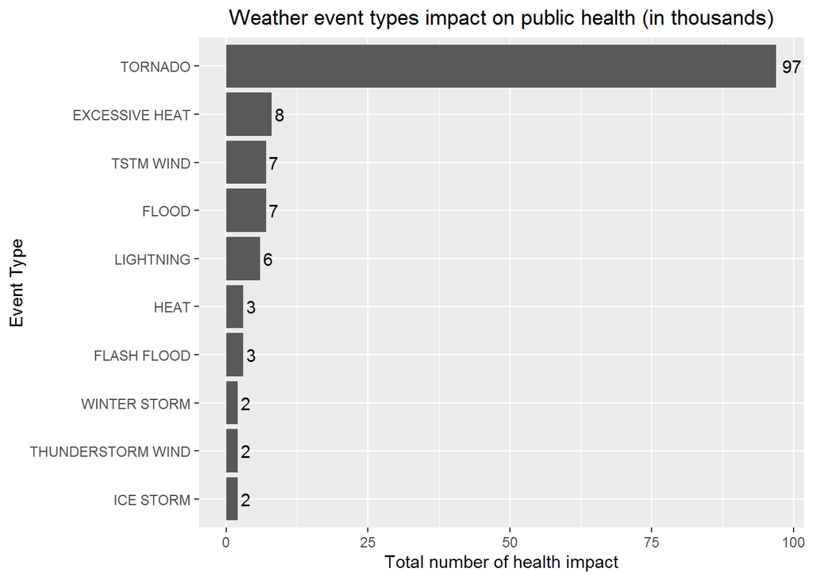

```r
HarmfulEvents %>%
  mutate(total_health_damage = round(total_health_damage / 1000),2) %>%
  ggplot(., aes(x = reorder(EVTYPE, total_health_damage), y = total_health_damage))+
  geom_bar(stat = 'identity')+
  coord_flip()+
  xlab("Event Type") +
  ylab("Total number of health impact") +
  ggtitle("Weather event types impact on public health (in thousands)") +
  theme(plot.title = element_text(hjust = 0.5))+
  geom_text(aes(label = total_health_damage), position = position_dodge(width = 1), hjust = -0.3)
```

[figure not shown]

```r
economicImpact %>%
  mutate(total_damage = round(total_damage / 1000000000),2) %>%
  ggplot(., aes(x = reorder(EVTYPE, total_damage), y = total_damage))+
  geom_bar(stat = 'identity')+
  coord_flip()+
  xlab("Event Type") +
  ylab("Total number of health impact") +
  ggtitle("Weather event types impact on public health (in billions)") +
  theme(plot.title = element_text(hjust = 0.5))+
  geom_text(aes(label = total_damage), position = position_dodge(width = 0.5), hjust = -0.05)
```